# examples_0403

In Adams, Massachusetts, 4 candidates (W through Z) are running in an election with a single winner. There are 11 voters (A through K) who each rank the candidates from 1 to 4, with 1 meaning first choice and 4 meaning last choice. Those rankings are shown below. Each column represents a single voter's ranking.

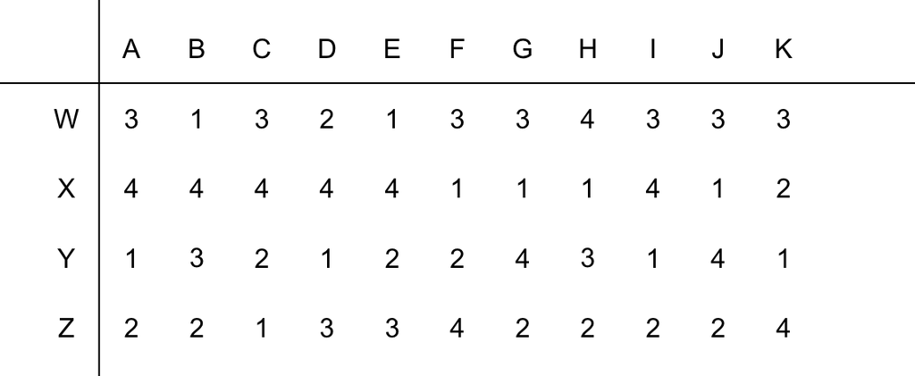

Who would win an [instant-runoff election](https://en.wikipedia.org/wiki/Instant-runoff_voting)?

Candidate WCandidate XCandidate YCandidate Z

First, there are 11 voters, so a candidate needs at least 6 votes to win a majority.

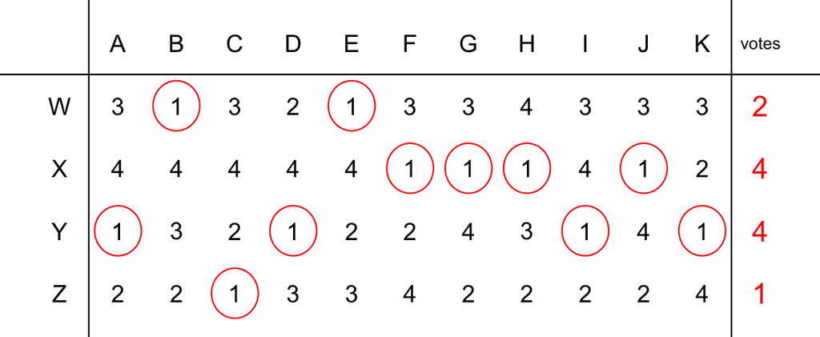

Nobody has a majority. Candidate Z has the fewest votes. Eliminate candidate Z from the contest. Each voter's vote goes to their top candidate still in the election.

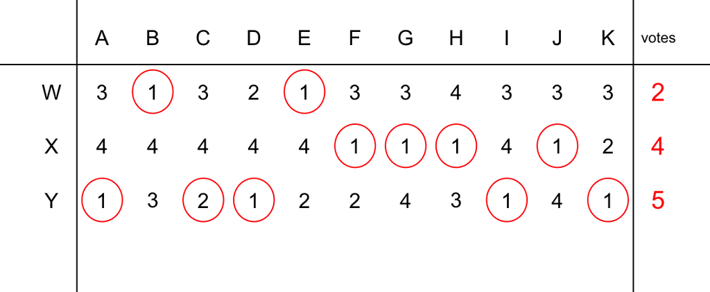

Nobody has a majority. Candidate W has the fewest votes. Eliminate candidate W from the contest. Each voter's vote goes to their top candidate still in the election.

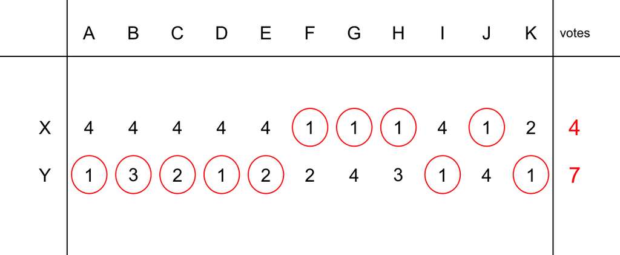

Candidate Y has gotten majority vote. Candidate Y wins!

In Adams, Massachusetts, 4 candidates (W through Z) are running in an election with a single winner. There are 11 voters (A through K) who each rank the candidates from 1 to 4, with 1 meaning first choice and 4 meaning last choice. Those rankings are shown below. Each column represents a single voter's ranking.

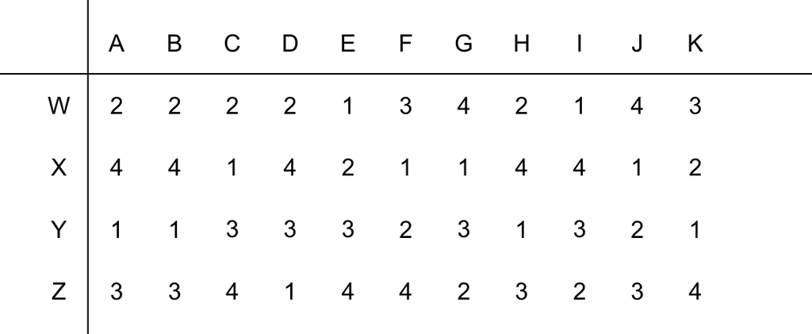

Who would win an [instant-runoff election](https://en.wikipedia.org/wiki/Instant-runoff_voting)?

Candidate WCandidate XCandidate YCandidate Z

First, there are 11 voters, so a candidate needs at least 6 votes to win a majority.

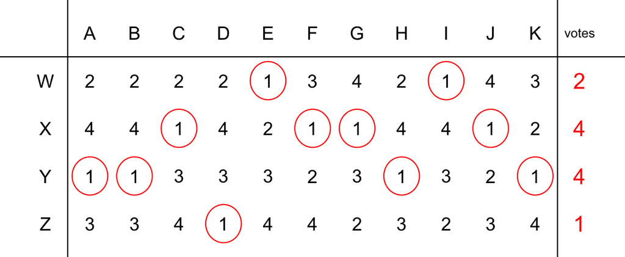

Nobody has a majority. Candidate Z has the fewest votes. Eliminate candidate Z from the contest. Each voter's vote goes to their top candidate still in the election.

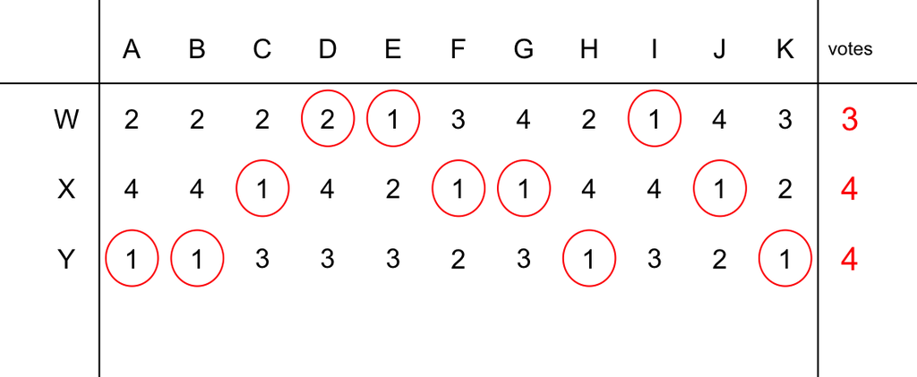

Nobody has a majority. Candidate W has the fewest votes. Eliminate candidate W from the contest. Each voter's vote goes to their top candidate still in the election.

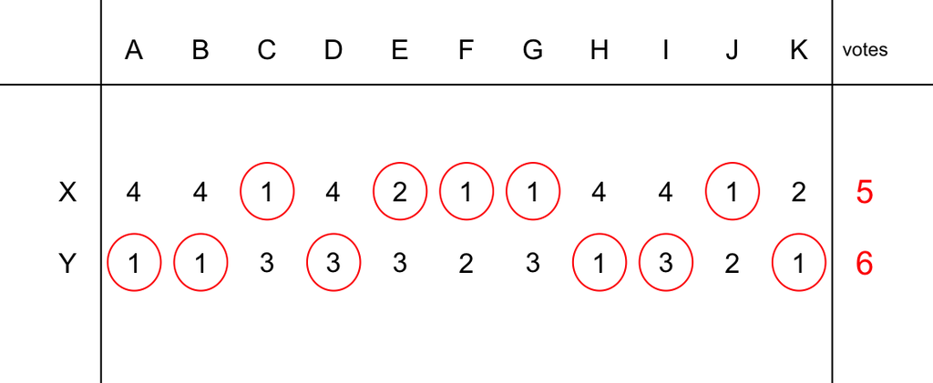

Candidate Y has gotten majority vote. Candidate Y wins!

In Adams, Massachusetts, 4 candidates (W through Z) are running in an election with a single winner. There are 11 voters (A through K) who each rank the candidates from 1 to 4, with 1 meaning first choice and 4 meaning last choice. Those rankings are shown below. Each column represents a single voter's ranking.

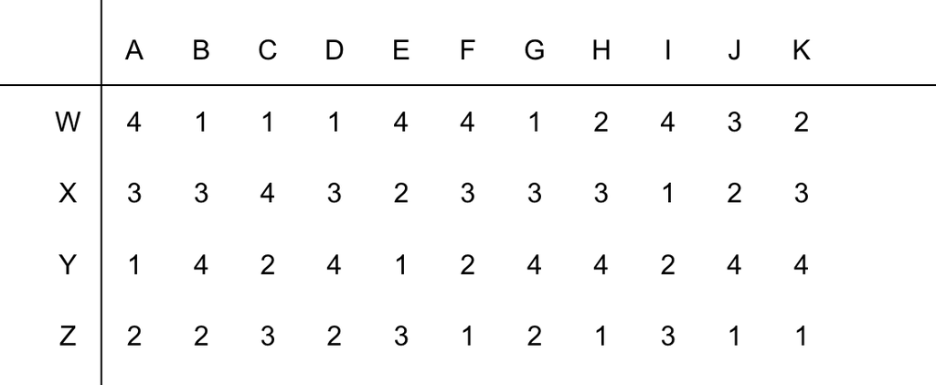

Who would win an [instant-runoff election](https://en.wikipedia.org/wiki/Instant-runoff_voting)?

Candidate WCandidate XCandidate YCandidate Z

First, there are 11 voters, so a candidate needs at least 6 votes to win a majority.

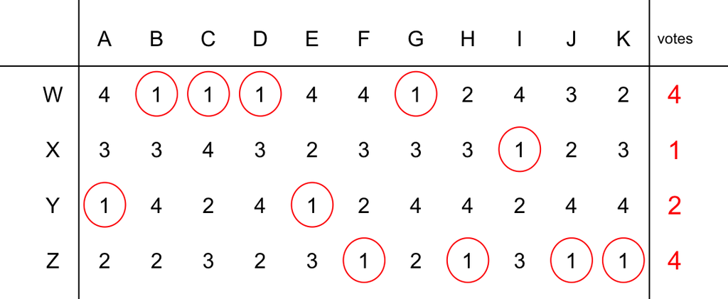

Nobody has a majority. Candidate X has the fewest votes. Eliminate candidate X from the contest. Each voter's vote goes to their top candidate still in the election.

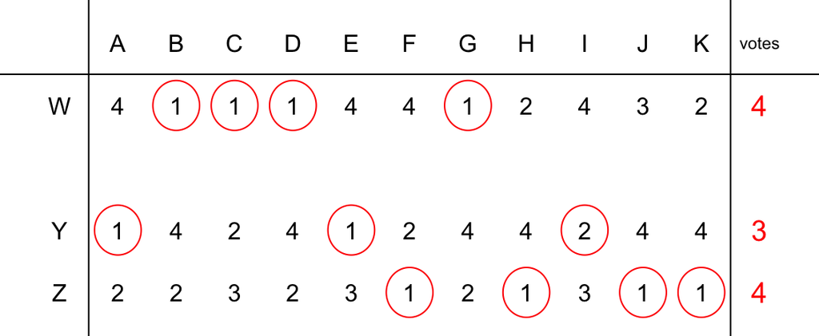

Nobody has a majority. Candidate Y has the fewest votes. Eliminate candidate Y from the contest. Each voter's vote goes to their top candidate still in the election.

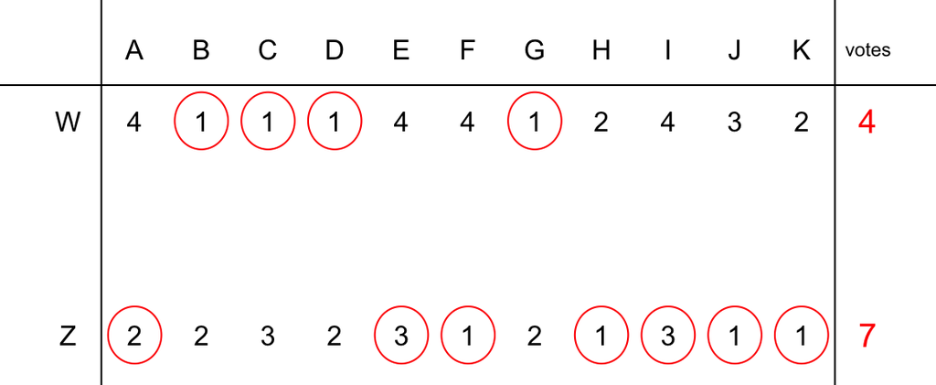

Candidate Z has gotten majority vote. Candidate Z wins!

In Adams, Massachusetts, 4 candidates (W through Z) are running in an election with a single winner. There are 9 voters (A through I) who each rank the candidates from 1 to 4, with 1 meaning first choice and 4 meaning last choice. Those rankings are shown below. Each column represents a single voter's ranking.

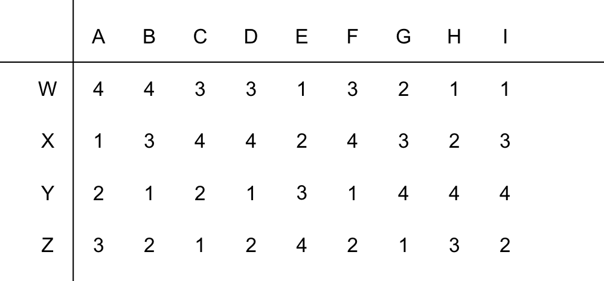

Who would win an [instant-runoff election](https://en.wikipedia.org/wiki/Instant-runoff_voting)?

Candidate WCandidate XCandidate YCandidate Z

First, there are 9 voters, so a candidate needs at least 5 votes to win a majority.

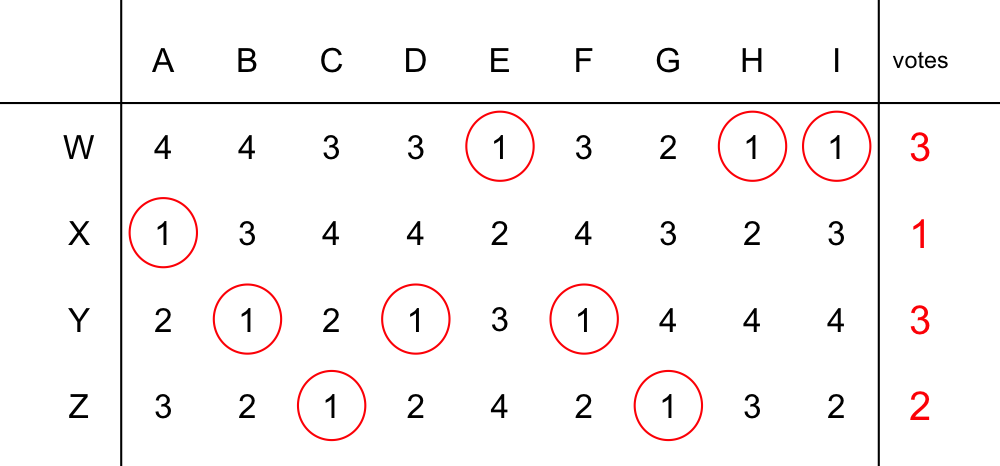

Nobody has a majority. Candidate X has the fewest votes. Eliminate candidate X from the contest. Each voter's vote goes to their top candidate still in the election.

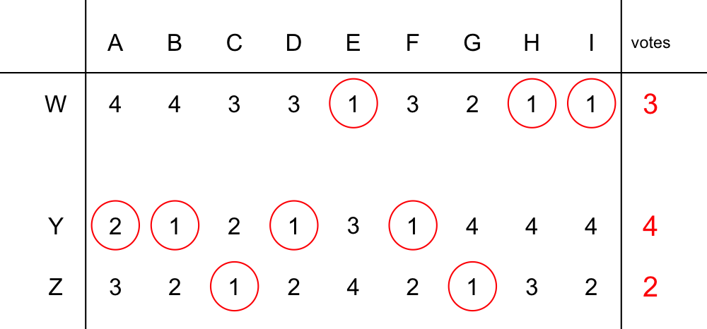

Nobody has a majority. Candidate Z has the fewest votes. Eliminate candidate Z from the contest. Each voter's vote goes to their top candidate still in the election.

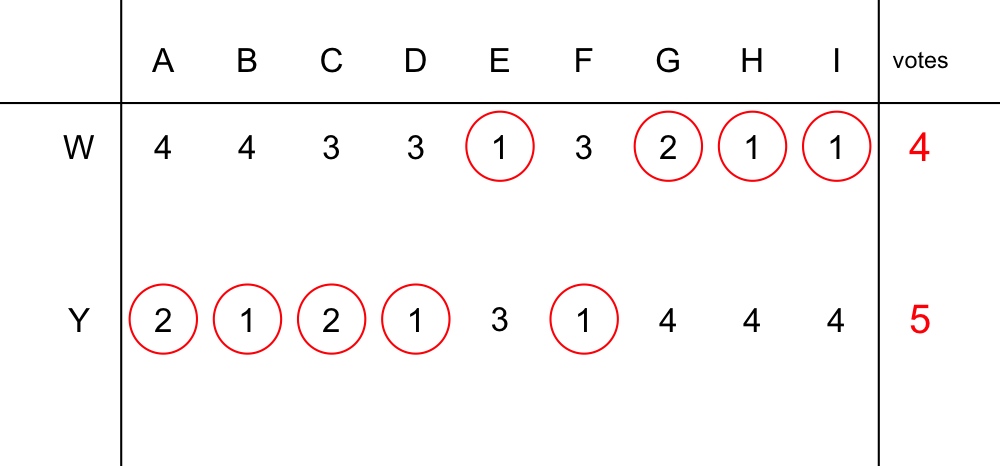

Candidate Y has gotten majority vote. Candidate Y wins!

In Adams, Massachusetts, 5 candidates (V through Z) are running in an election with a single winner. There are 12 voters (A through L) who each rank the candidates from 1 to 5, with 1 meaning first choice and 5 meaning last choice. Those rankings are shown below. Each column represents a single voter's ranking.

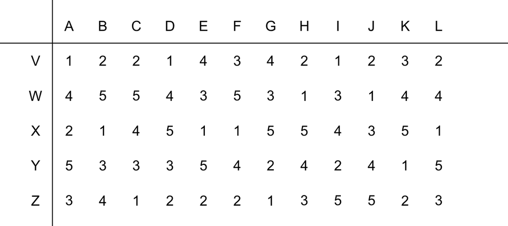

Who would win an [instant-runoff election](https://en.wikipedia.org/wiki/Instant-runoff_voting)?

Candidate VCandidate WCandidate XCandidate YCandidate Z

First, there are 12 voters, so a candidate needs at least 7 votes to win a majority.

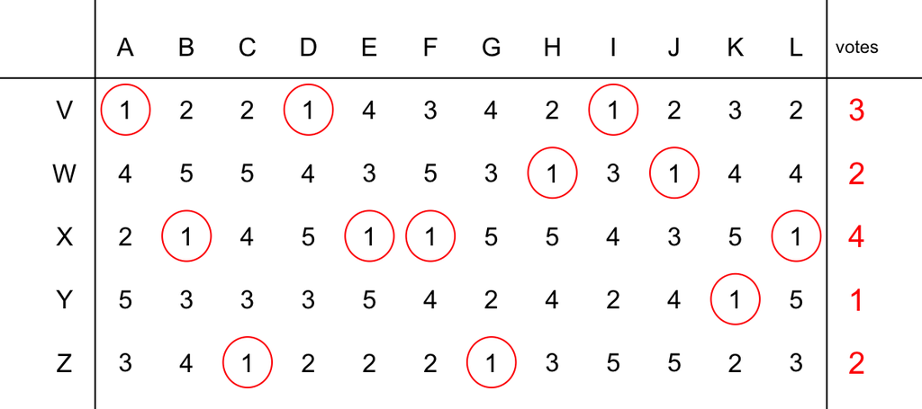

Nobody has a majority. Candidate Y has the fewest votes. Eliminate candidate Y from the contest. Each voter's vote goes to their top candidate still in the election.

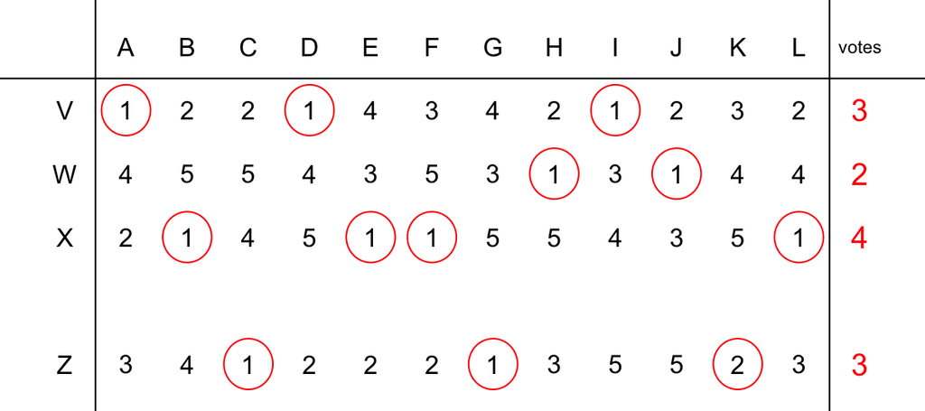

Nobody has a majority. Candidate W has the fewest votes. Eliminate candidate W from the contest. Each voter's vote goes to their top candidate still in the election.

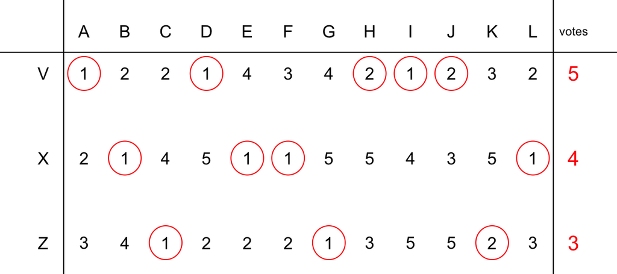

Nobody has a majority. Candidate Z has the fewest votes. Eliminate candidate Z from the contest. Each voter's vote goes to their top candidate still in the election.

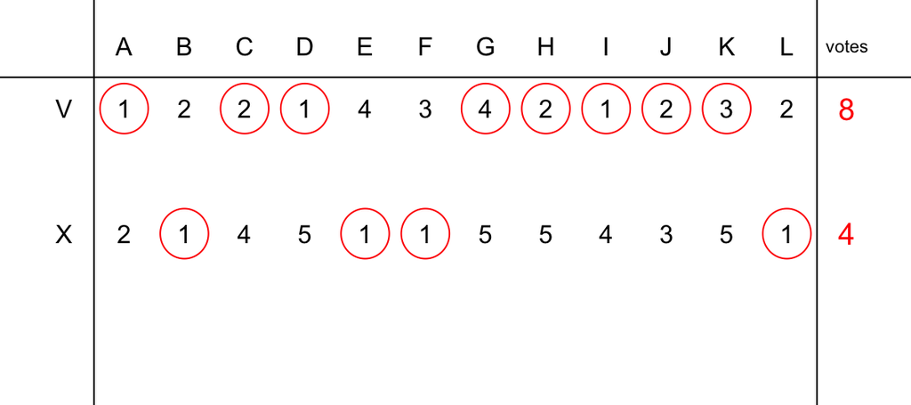

Candidate V has gotten majority vote. Candidate V wins!

In Adams, Massachusetts, 5 candidates (V through Z) are running in an election with a single winner. There are 11 voters (A through K) who each rank the candidates from 1 to 5, with 1 meaning first choice and 5 meaning last choice. Those rankings are shown below. Each column represents a single voter's ranking.

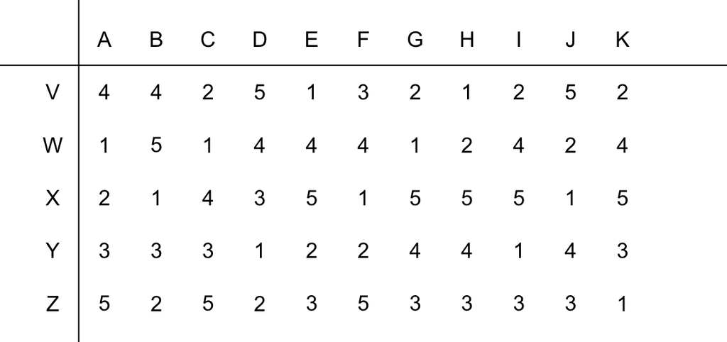

Who would win an [instant-runoff election](https://en.wikipedia.org/wiki/Instant-runoff_voting)?

Candidate VCandidate WCandidate XCandidate YCandidate Z

First, there are 11 voters, so a candidate needs at least 6 votes to win a majority.

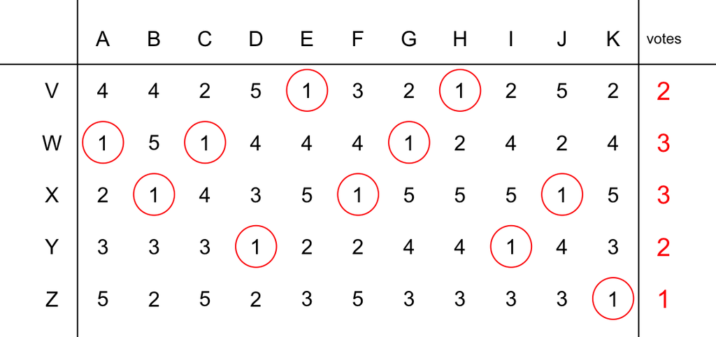

Nobody has a majority. Candidate Z has the fewest votes. Eliminate candidate Z from the contest. Each voter's vote goes to their top candidate still in the election.

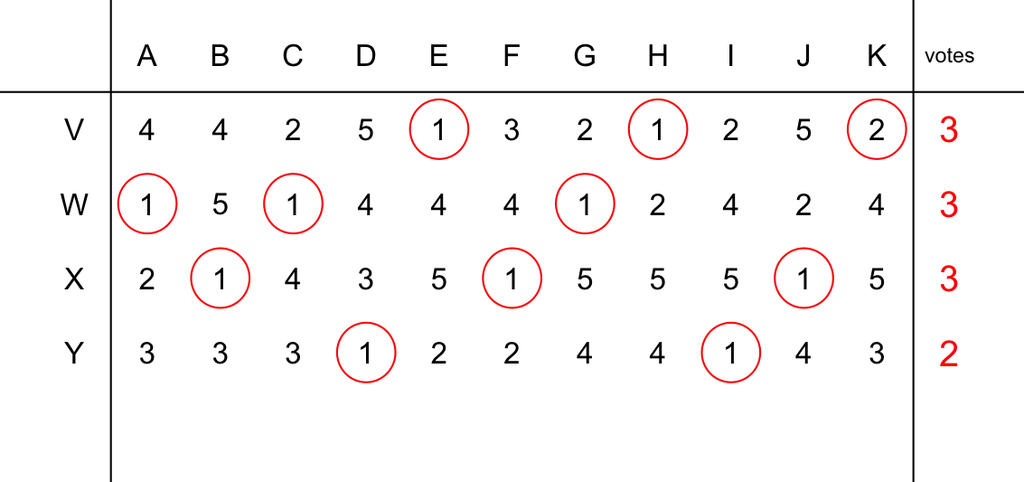

Nobody has a majority. Candidate Y has the fewest votes. Eliminate candidate Y from the contest. Each voter's vote goes to their top candidate still in the election.

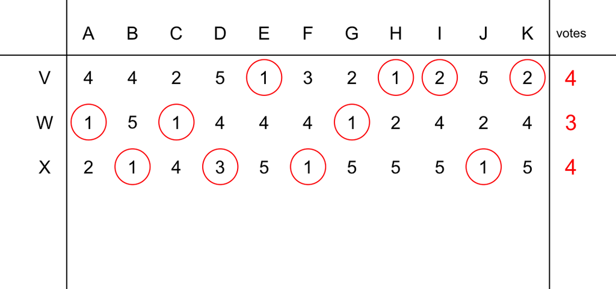

Nobody has a majority. Candidate W has the fewest votes. Eliminate candidate W from the contest. Each voter's vote goes to their top candidate still in the election.

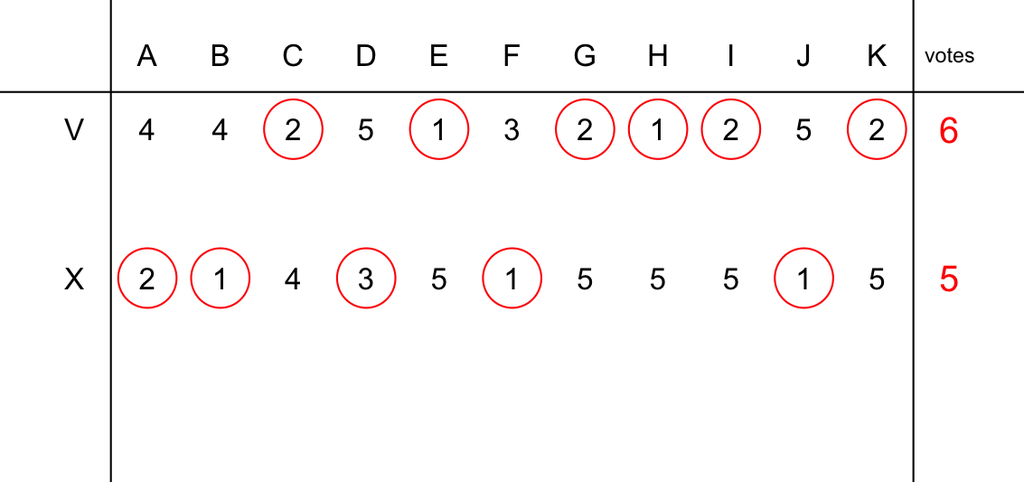

Candidate V has gotten majority vote. Candidate V wins!

In Adams, Massachusetts, 4 candidates (W through Z) are running in an election with a single winner. There are 12 voters (A through L) who each rank the candidates from 1 to 4, with 1 meaning first choice and 4 meaning last choice. Those rankings are shown below. Each column represents a single voter's ranking.

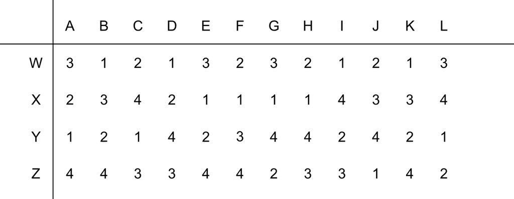

Who would win an [instant-runoff election](https://en.wikipedia.org/wiki/Instant-runoff_voting)?

Candidate WCandidate XCandidate YCandidate Z